# Dietary Kinetics of a PFAS Mixture in American Toads (*Anaxyrus americanus*)

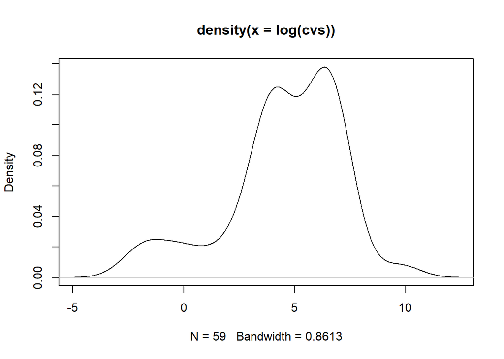

```r
plot(density(log(cvs)))
```

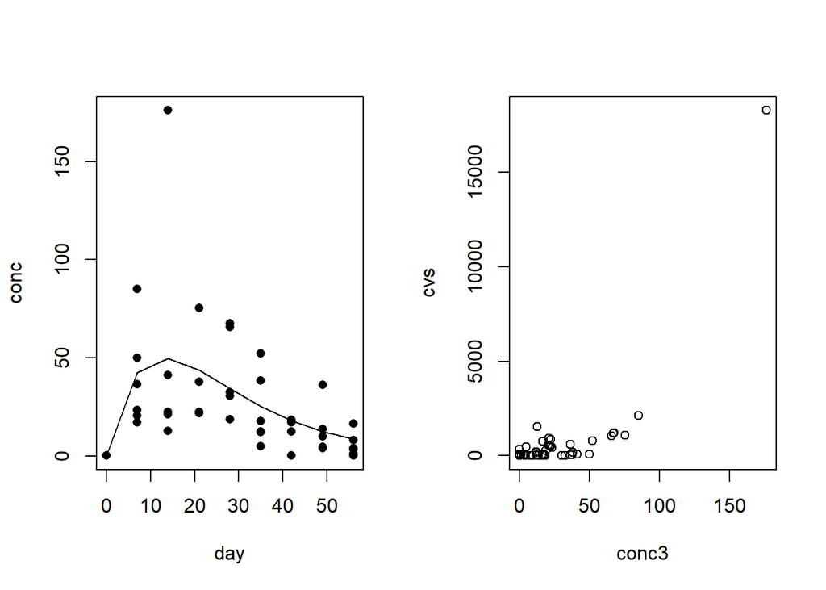

```r
subdata$cvs <- cvs



#plot(cvs~conc3, data=subdata, log="")

#plot(cvs~conc3, data=subdata, log="xy")





par(mfrow=c(1,2))

plot(y~x, pch=16, xlab='day', ylab='conc')

lines(predict(d)[order(x)]~sort(x), lwd=1, col='black')

plot(cvs~conc3, data=subdata, log="")
```

```r
par(mfrow=c(1,1))
```

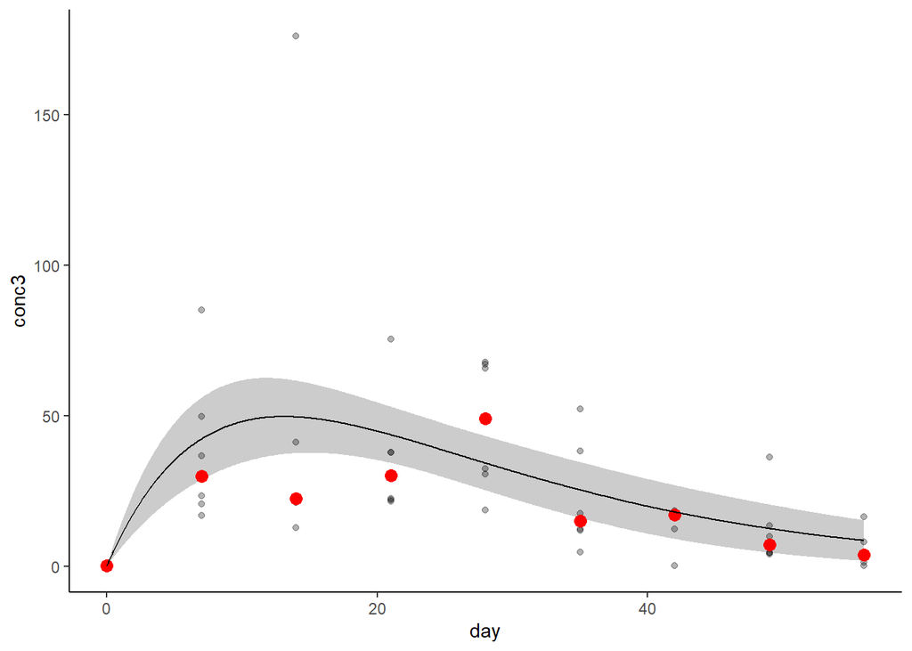

```r
#ggplot() +

#  geom_ribbon(data=nlsplpred,aes(x=day,ymin=fit.lwr,ymax=fit.upr),alpha=0.25) +

#  geom_point(data=toadsumm3%>%filter(tissue=="Liver"&PFAS=="PFOS"&day%in%c(0:56)),aes(x=day,y=median),

#             size=2,alpha=0.3) +

#  geom_line(data=nlsplpred,aes(x=day,y=fit.fit)) +

#  theme_classic()





ggplot() +

  geom_ribbon(data=nls8lpred,aes(x=day,ymin=fit.lwr,ymax=fit.upr),alpha=0.25) +

  geom_point(data=toad%>%filter(tissue=="Whole Body"&PFAS=="8:2 FTS"&day%in%c(0:56)),aes(x=day,y=conc3),

             size=1.5,alpha=0.3) +

  geom_point(data=toadsumm3%>%filter(tissue=="Whole Body"&PFAS=="8:2 FTS"&day%in%c(0:56)),aes(x=day,y=median),

             size=3, color="red") +

  geom_line(data=nls8lpred,aes(x=day,y=fit.fit)) +

  theme_classic()
```

#### PFOS liver up and down params via `nls()`?

Starts based on combo of OECD linear and `nls()`.

Does not work very well, too noisy or too simple?

Either way, equal uptake and elimination does not make sense.

```r
nlspl2 <- nlsLM(conc3~259.767+((697.138*(3/7)*k01)/(V*(k01-k10)))*(exp(-k10*day)-exp(-k01*day)),

               data=toad%>%filter(PFAS=="PFOS"&tissue=="Liver"&day%in%c(0:56)),

               start=list(V=0.5, k01=0.057, k10=0.007) #,trace=T, algorithm="port",control=list(minFactor=1e-20, maxiter=100, warnOnly=T)

             )

summary(nlspl2)
```

```
##
## Formula: conc3 ~ 259.767 + ((697.138 * (3/7) * k01)/(V * (k01 - k10))) *
##     (exp(-k10 * day) - exp(-k01 * day))
##
## Parameters:
##     Estimate Std. Error t value Pr(>|t|)
## V    0.10551   76.64391   0.001    0.999
## k01  0.02646   19.22503   0.001    0.999
## k10  0.02647   19.22146   0.001    0.999
##
## Residual standard error: 392.3 on 56 degrees of freedom
##
## Number of iterations to convergence: 11
## Achieved convergence tolerance: 1.49e-08
```

```r
nlspl2pred <- data.frame(predFit(nlspl2, newdata=data.frame(day=seq(from=0, to=56, by=0.1)), interval="confidence", se.fit=T, type="response"))

nlspl2pred$day <- c(seq(from=0,to=56,by=0.1))
```

##### LOOCV

```r
subdata <- toad%>%filter(PFAS=="PFOS"&tissue=="Liver"&day%in%c(0:56))



y <- subdata$conc3

x <- subdata$day

n <- length(x)



cvs <- rep(0,n)



for(j in seq(n)){

  ys <- y[-j]

  xs <- x[-j]

  d <- nlsLM(ys~259.767+((697.138*(3/7)*k01)/(V*(k01-k10)))*(exp(-k10*xs)-exp(-k01*xs)),

           start=list(V=0.5, k01=0.057, k10=0.007))

  cvs[j] <- (y[j]-predict(d,data.frame(xs=x[j])))^2

  print(paste0(j," of ",n," finished (",round(j/n*100),"%)"))

}
```

```
## [1] "1 of 59 finished (2%)"
## [1] "2 of 59 finished (3%)"
## [1] "3 of 59 finished (5%)"
## [1] "4 of 59 finished (7%)"
## [1] "5 of 59 finished (8%)"
## [1] "6 of 59 finished (10%)"
## [1] "7 of 59 finished (12%)"
## [1] "8 of 59 finished (14%)"
## [1] "9 of 59 finished (15%)"
## [1] "10 of 59 finished (17%)"
## [1] "11 of 59 finished (19%)"
## [1] "12 of 59 finished (20%)"
## [1] "13 of 59 finished (22%)"
## [1] "14 of 59 finished (24%)"
## [1] "15 of 59 finished (25%)"
```

[output cut: 44 more lines]

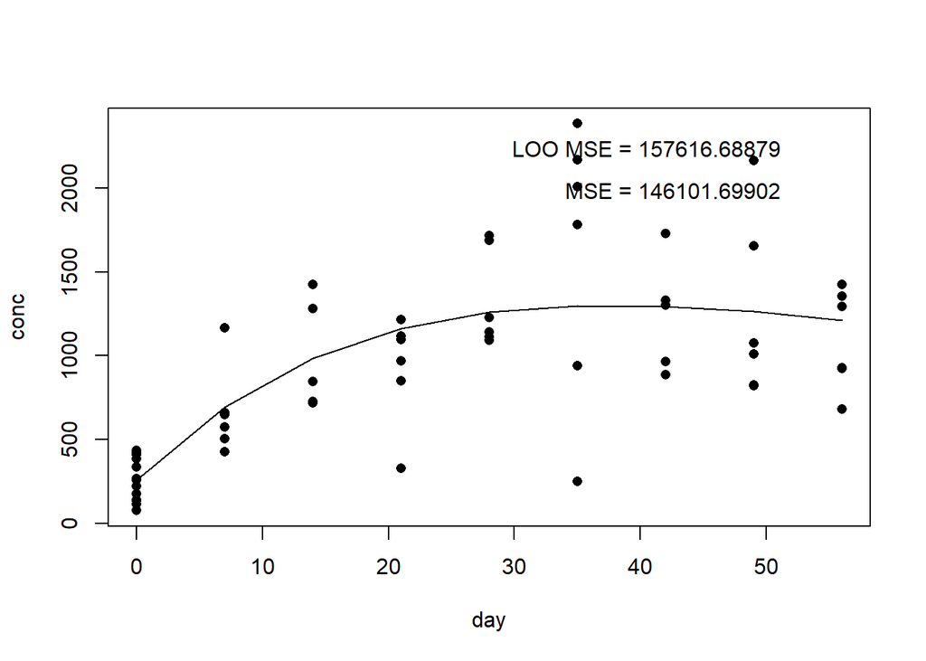

```r
plot(y~x, pch=16, xlab='day', ylab='conc')

d <- nlsLM(y~259.767+((697.138*(3/7)*k01)/(V*(k01-k10)))*(exp(-k10*x)-exp(-k01*x)),

           start=list(V=0.5, k01=0.057, k10=0.007))

lines(predict(d)[order(x)]~sort(x), lwd=1, col='black')

usr <- par("usr")

text(usr[1] + 0.9*(usr[2]-usr[1]), usr[3] + 0.9*(usr[4]-usr[3]), paste("LOO MSE", "=", round(mean(cvs), 5)), pos=2)

text(usr[1] + 0.9*(usr[2]-usr[1]), usr[3] + 0.8*(usr[4]-usr[3]), paste("MSE", "=", round(mean(resid(d)^2), 5)), pos=2)
```

```r
(146101-157617)/146101
```

```
## [1] -0.07882218
```

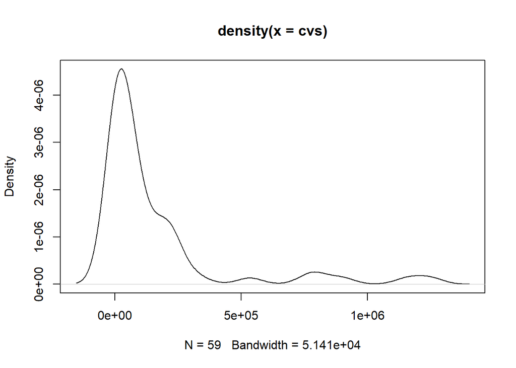

```r
#7.9% impact on prediction



plot(density(cvs))
```

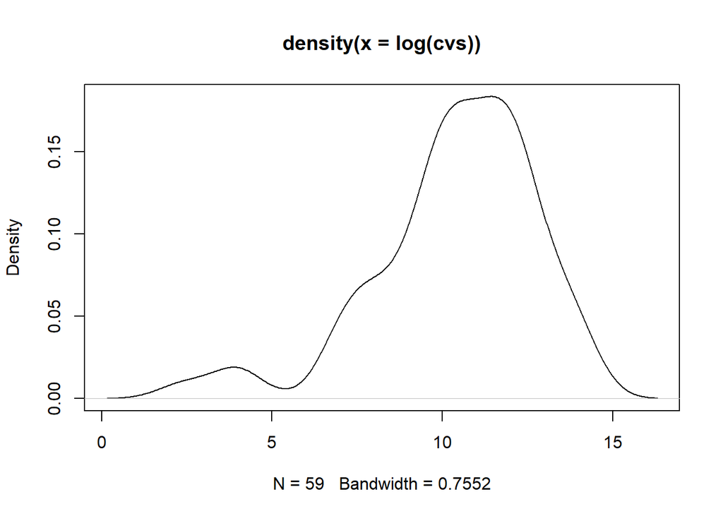

```r
plot(density(log(cvs)))
```

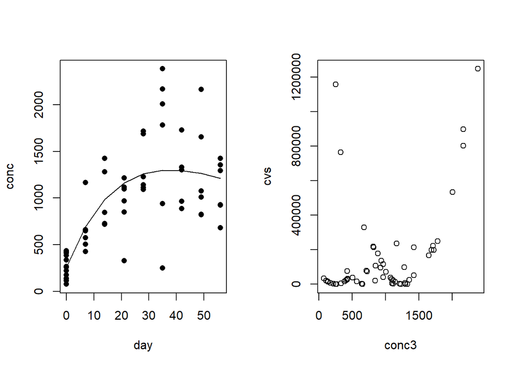

```r
subdata$cvs <- cvs



#plot(cvs~conc3, data=subdata, log="")

#plot(cvs~conc3, data=subdata, log="xy")





par(mfrow=c(1,2))

plot(y~x, pch=16, xlab='day', ylab='conc')

lines(predict(d)[order(x)]~sort(x), lwd=1, col='black')

plot(cvs~conc3, data=subdata, log="")
```

```r
par(mfrow=c(1,1))
```

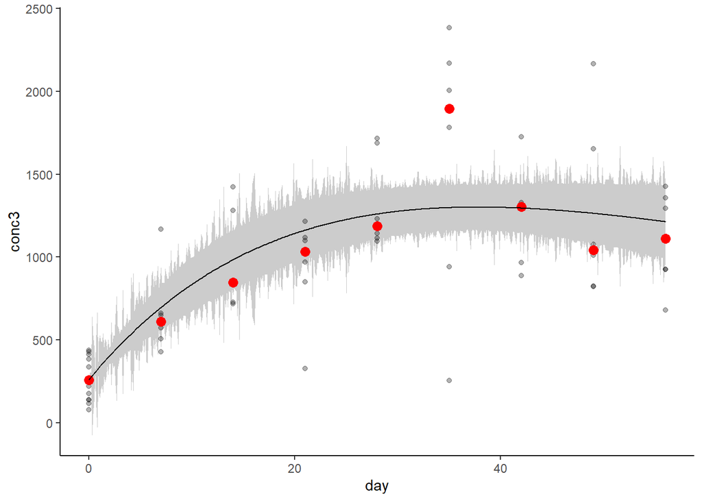

```r
#ggplot() +

#  geom_ribbon(data=nlsplpred,aes(x=day,ymin=fit.lwr,ymax=fit.upr),alpha=0.25) +

#  geom_point(data=toadsumm3%>%filter(tissue=="Liver"&PFAS=="PFOS"&day%in%c(0:56)),aes(x=day,y=median),

#             size=2,alpha=0.3) +

#  geom_line(data=nlsplpred,aes(x=day,y=fit.fit)) +

#  theme_classic()





ggplot() +

  geom_ribbon(data=nlspl2pred,aes(x=day,ymin=fit.lwr,ymax=fit.upr),alpha=0.25) +

  geom_point(data=toad%>%filter(tissue=="Liver"&PFAS=="PFOS"&day%in%c(0:56)),aes(x=day,y=conc3),

             size=1.5,alpha=0.3) +

  geom_point(data=toadsumm3%>%filter(tissue=="Liver"&PFAS=="PFOS"&day%in%c(0:56)),aes(x=day,y=median),

             size=3, color="red") +

  geom_line(data=nlspl2pred,aes(x=day,y=fit.fit)) +

  theme_classic()
```

#### 8:2 FTS liver up and down params via `nls()`?

Starts based on combo of OECD linear and `nls()`.

Does not work very well, too noisy or too simple?

Either way, equal uptake and elimination does not make sense.

```r
# 0.1+((885.228*k01)/(V*(k01-0.108)))*(exp(-0.108*xs)-exp(-k01*xs)),

#           start=list(V=2, k01=0.05)









nls8l2 <- nlsLM(conc3~0.1+((885.228*(3/7)*k01)/(V*(k01-k10)))*(exp(-k10*day)-exp(-k01*day)),

               data=toad%>%filter(PFAS=="8:2 FTS"&tissue=="Liver"&day%in%c(0:56)),

               start=list(V=2, k01=0.05, k10=0.108) #,trace=T, algorithm="port",control=list(minFactor=1e-20, maxiter=100, warnOnly=T)

             )

summary(nls8l2)
```

```
##
## Formula: conc3 ~ 0.1 + ((885.228 * (3/7) * k01)/(V * (k01 - k10))) * (exp(-k10 *
##     day) - exp(-k01 * day))
##
## Parameters:
##      Estimate Std. Error t value Pr(>|t|)
## V   1.488e+00  2.219e+03   0.001    0.999
## k01 7.348e-02  1.096e+02   0.001    0.999
## k10 7.346e-02  1.096e+02   0.001    0.999
##
## Residual standard error: 24.33 on 56 degrees of freedom
##
## Number of iterations to convergence: 7
## Achieved convergence tolerance: 1.49e-08
```

```r
nls8l2pred <- data.frame(predFit(nls8l2, newdata=data.frame(day=seq(from=0, to=56, by=0.1)), interval="confidence", se.fit=T, type="response"))

nls8l2pred$day <- c(seq(from=0,to=56,by=0.1))
```

##### LOOCV

```r
subdata <- toad%>%filter(PFAS=="8:2 FTS"&tissue=="Liver"&day%in%c(0:56))



y <- subdata$conc3

x <- subdata$day

n <- length(x)



cvs <- rep(0,n)



for(j in seq(n)){

  ys <- y[-j]

  xs <- x[-j]

  d <- nlsLM(ys~0.1+((885.228*(3/7)*k01)/(V*(k01-k10)))*(exp(-k10*xs)-exp(-k01*xs)),

           start=list(V=2, k01=0.05, k10=0.108))

  cvs[j] <- (y[j]-predict(d,data.frame(xs=x[j])))^2

  print(paste0(j," of ",n," finished (",round(j/n*100),"%)"))

}
```

```
## [1] "1 of 59 finished (2%)"
## [1] "2 of 59 finished (3%)"
## [1] "3 of 59 finished (5%)"
## [1] "4 of 59 finished (7%)"
## [1] "5 of 59 finished (8%)"
## [1] "6 of 59 finished (10%)"
## [1] "7 of 59 finished (12%)"
## [1] "8 of 59 finished (14%)"
## [1] "9 of 59 finished (15%)"
## [1] "10 of 59 finished (17%)"
## [1] "11 of 59 finished (19%)"
## [1] "12 of 59 finished (20%)"
## [1] "13 of 59 finished (22%)"
## [1] "14 of 59 finished (24%)"
## [1] "15 of 59 finished (25%)"
```

[output cut: 44 more lines]

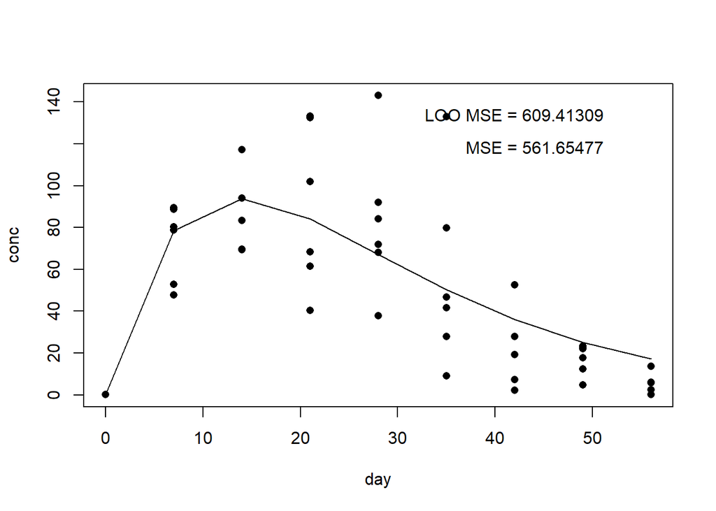

```r
plot(y~x, pch=16, xlab='day', ylab='conc')

d <- nlsLM(y~0.1+((885.228*(3/7)*k01)/(V*(k01-k10)))*(exp(-k10*x)-exp(-k01*x)),

           start=list(V=2, k01=0.05, k10=0.108))

lines(predict(d)[order(x)]~sort(x), lwd=1, col='black')

usr <- par("usr")

text(usr[1] + 0.9*(usr[2]-usr[1]), usr[3] + 0.9*(usr[4]-usr[3]), paste("LOO MSE", "=", round(mean(cvs), 5)), pos=2)

text(usr[1] + 0.9*(usr[2]-usr[1]), usr[3] + 0.8*(usr[4]-usr[3]), paste("MSE", "=", round(mean(resid(d)^2), 5)), pos=2)
```

```r
(561.65-609.42)/561.65
```

```
## [1] -0.08505297
```

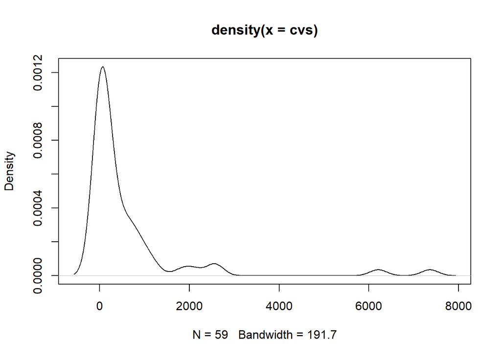

```r
#8.5% impact on prediction



plot(density(cvs))
```

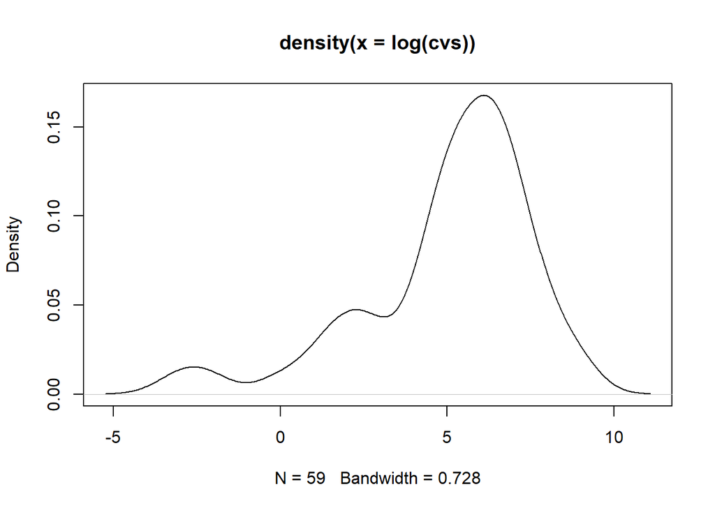

```r
plot(density(log(cvs)))
```

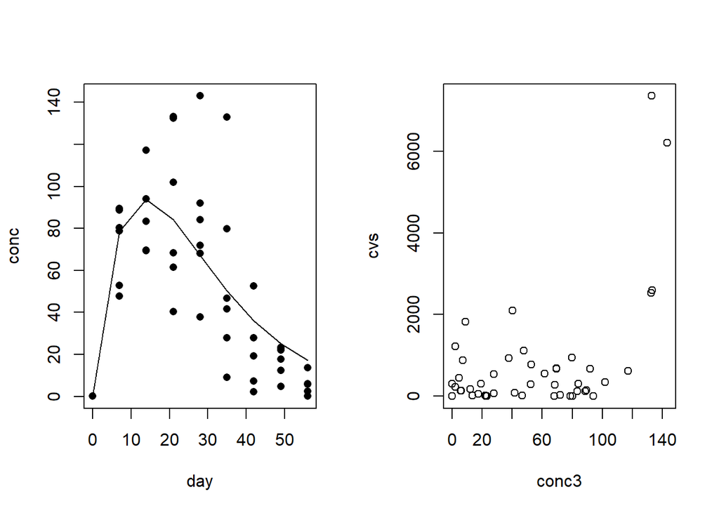

```r
subdata$cvs <- cvs



#plot(cvs~conc3, data=subdata, log="")

#plot(cvs~conc3, data=subdata, log="xy")





par(mfrow=c(1,2))

plot(y~x, pch=16, xlab='day', ylab='conc')

lines(predict(d)[order(x)]~sort(x), lwd=1, col='black')

plot(cvs~conc3, data=subdata, log="")
```

```r
par(mfrow=c(1,1))
```

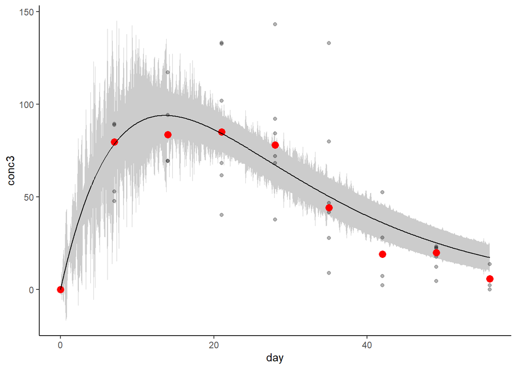

```r
#ggplot() +

#  geom_ribbon(data=nlsplpred,aes(x=day,ymin=fit.lwr,ymax=fit.upr),alpha=0.25) +

#  geom_point(data=toadsumm3%>%filter(tissue=="Liver"&PFAS=="PFOS"&day%in%c(0:56)),aes(x=day,y=median),

#             size=2,alpha=0.3) +

#  geom_line(data=nlsplpred,aes(x=day,y=fit.fit)) +

#  theme_classic()





ggplot() +

  geom_ribbon(data=nls8l2pred,aes(x=day,ymin=fit.lwr,ymax=fit.upr),alpha=0.25) +

  geom_point(data=toad%>%filter(tissue=="Liver"&PFAS=="8:2 FTS"&day%in%c(0:56)),aes(x=day,y=conc3),

             size=1.5,alpha=0.3) +

  geom_point(data=toadsumm3%>%filter(tissue=="Liver"&PFAS=="8:2 FTS"&day%in%c(0:56)),aes(x=day,y=median),

             size=3, color="red") +

  geom_line(data=nls8l2pred,aes(x=day,y=fit.fit)) +

  theme_classic()
```

#### PFOS liver via `rbioacc`

```r
#697.138*(3/7)



dataf <- toad |>

  filter(tissue=="Liver"&PFAS=="PFOS") |>

  dplyr::select(toadID, day, conc3) |>

  rename(time=day,

         conc=conc3) |>

  mutate(expf=298,

         replicate=toadID)



modeldf <- modelData(dataf, time_accumulation=28)

fitmoddf <- fitTK(modeldf, iter=50000)
```

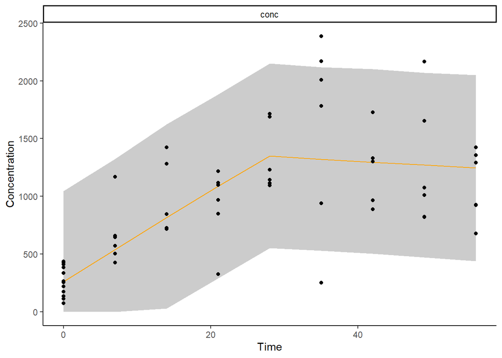

```r
plot(fitmoddf)
```

```r
quantile_table(fitmoddf)
```

|  | 2.5% | 50% | 97.5% | parameter |
| --- | --- | --- | --- | --- |
| ku | 1.129319e-01 | 1.346214e-01 | 0.18828412 | ku |
| kee | 1.278503e-05 | 1.238883e-03 | 0.01260865 | kee |
| sigmaConc | 3.296134e+02 | 3.931086e+02 | 479.30923984 | sigmaConc |

```r
mean(bioacc_metric(fitmoddf)$BMFk)
```

```
## [1] 1262.646
```

```r
median(bioacc_metric(fitmoddf)$BMFk)
```

```
## [1] 105.8293
```

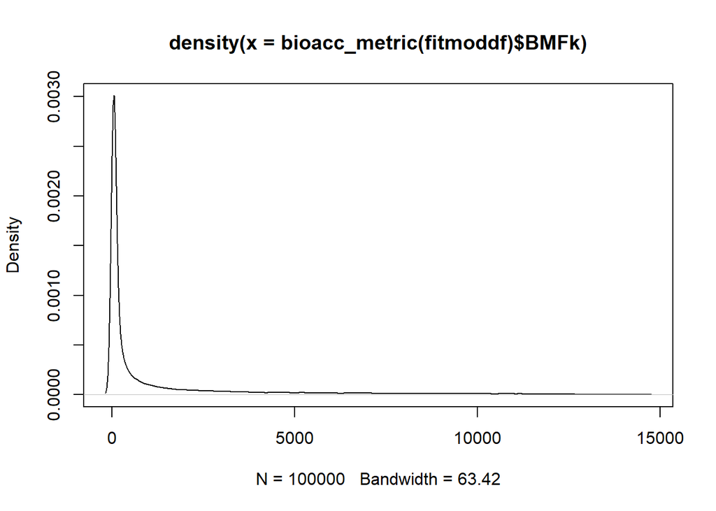

```r
plot(density(bioacc_metric(fitmoddf)$BMFk))
```

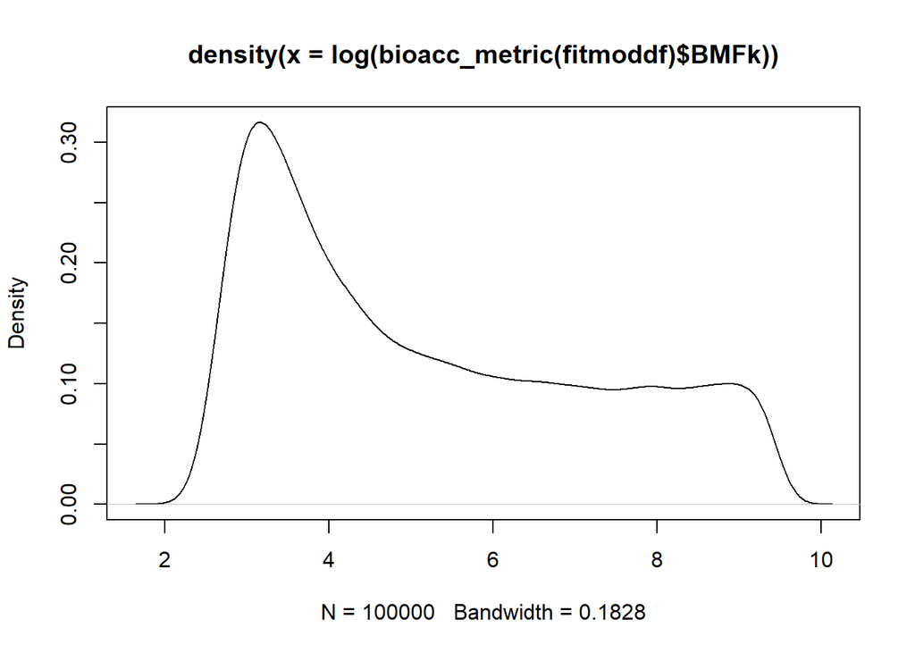

```r
plot(density(log(bioacc_metric(fitmoddf)$BMFk)))
```

```r
t95(fitmoddf)
```

```
## [1] 2418.091
```

#### 8:2 FTS liver via `rbioacc`

```r
#885.228*(3/7)



dataf <- toad |>

  filter(tissue=="Liver"&PFAS=="8:2 FTS") |>

  dplyr::select(toadID, day, conc3) |>

  rename(time=day,

         conc=conc3) |>

  mutate(expf=379,

         replicate=as.numeric(factor(toadID)))



modeldf <- modelData(dataf, time_accumulation=28)

fitmoddf <- fitTK(modeldf, iter=50000)
```

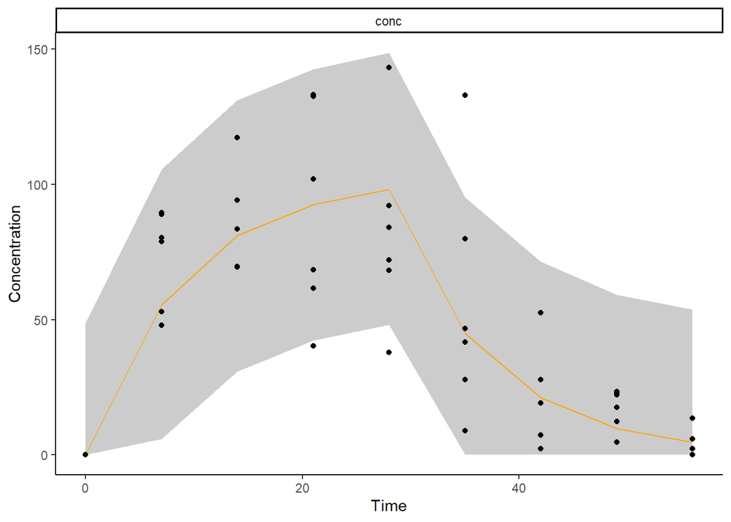

```r
plot(fitmoddf)
```

```r
quantile_table(fitmoddf)
```

|  | 2.5% | 50% | 97.5% | parameter |
| --- | --- | --- | --- | --- |
| ku | 0.02257953 | 0.03010511 | 0.04123915 | ku |
| kee | 0.08008792 | 0.11087093 | 0.15982271 | kee |
| sigmaConc | 20.57688770 | 24.49670003 | 29.92035408 | sigmaConc |

```r
mean(bioacc_metric(fitmoddf)$BMFk)
```

```
## [1] 0.2718173
```

```r
median(bioacc_metric(fitmoddf)$BMFk)
```

```
## [1] 0.2715337
```

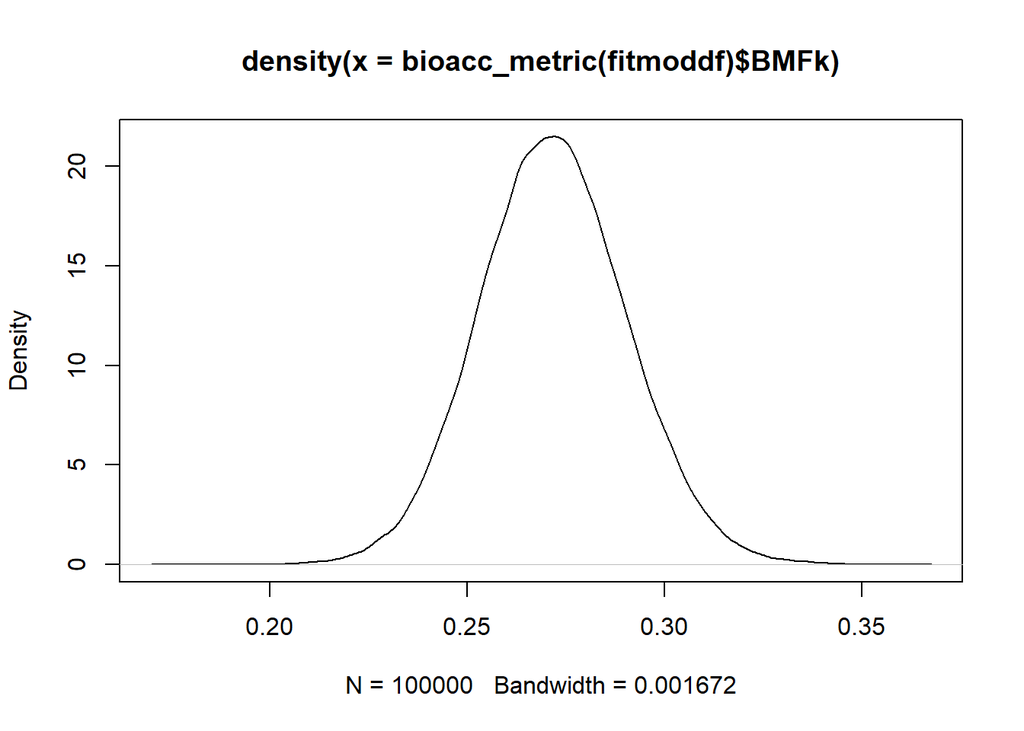

```r
plot(density(bioacc_metric(fitmoddf)$BMFk))
```

```r
t95(fitmoddf)
```

```
## [1] 27.02
```

### Dynamic Compartment Model

Tarazona has function for dynamic single compartment, which is great, but as we have both, we not try to model the flow?

Concerns include the lack of mass balance (no blood and no tissue mass or volume measurements).

Other concerns include assumption of model flows.

#### PFOS liver and whole body ODE

PFOS predicts fit liver data well, but not whole body.

```r
pkmodel <- function(time, state, parmeters) {

  with(as.list(c(state, parmeters)), {

    dbod <- k21*liv-k12*bod-kel*bod

    dliv <- k12*bod-k21*liv#-kel2*liv

    list(c(dbod, dliv))

  })

}



state <- c(bod = 26.568, liv = 259.767) # initial concs

parmeters <- c(k12 = 0.146,

               k21 = 0.007,

               kel = 0.007)#,

               #kel2 = 0.1)

times <- seq(0, 56, by=1) # start points to end points

dose_data <- data.frame(

  var=c("bod"),

  time=c(0,2,5,7,9,12,14,16,19,21,23,26),

  value=c(as.numeric(697.138*0.169)),

  method="add"

)









# calcuate differential equation with parameters

# and initialized state values

#out <- ode(y = state,

#           times = times,

#           func = pkmodel,

#           parms = parmeters,

#           events = list(data=dose_data))

#out <- as.data.frame(out)

#

#par(mfrow=c(1,2), mai=c(0.8,0.8,0.1,0.1))

#plot(out$time,

#     out$liv,

#     xlab = "Time (day)",

#     ylab= "PFOS Concentration (ug/kg)",

#     type = 'l',ylim=c(0,2750), bty="l")

#points(conc3~day, data=toad%>%filter(PFAS=="PFOS"&tissue=="Liver"), col="black", pch=4)

#legend("topleft", c("Whole Body (minus liver)", "Liver"), col=c("Red","Black"), pch=c(3,4), lty=c(2,1), bty="n")

#plot(out$time,

#     out$bod,

#     type="l",

#     lty=2,

#     col="red",

#     xlab = "Time (day)",

#     ylab= "PFOS Concentration (ug/kg)",

#     ylim=c(0,2750), bty="l")

#points(conc3~day, data=toad%>%filter(PFAS=="PFOS"&tissue=="Whole Body"), col="red", pch=3)

#par(mfrow=c(1,2), mai=c(1,1,0.5,0.5))





#dat <- data.frame(

#  time=seq(0,56,7),

#  liv=toad%>%filter(PFAS=="PFOS"&tissue=="liver")%>%group_by(day)%>%summarize(liv=mean(conc2))%>%ungroup()%>%dplyr::select(liv),

#  bod=toad%>%filter(PFAS=="PFOS"&tissue=="wholebody")%>%group_by(day)%>%summarize(bod=mean(conc2))%>%ungroup()%>%dplyr::select(bod)

#  #time=toad%>%filter(PFAS=="PFOS"&tissue=="liver")%>%dplyr::select(day)%>%dplyr::rename(time=day),

#  time=toad$day[toad$PFAS=="PFOS"&toad$tissue=="liver"],

#  #liv=toad%>%filter(PFAS=="PFOS"&tissue=="liver")%>%dplyr::select(conc2)%>%dplyr::rename(liv=conc2),

#  liv=toad$conc2[toad$PFAS=="PFOS"&toad$tissue=="liver"],

#  #bod=toad%>%filter(PFAS=="PFOS"&tissue=="wholebody")%>%dplyr::select(conc2)%>%dplyr::rename(bod=conc2)

#  bod=toad$conc2[toad$PFAS=="PFOS"&toad$tissue=="wholebody"]

#)



dat <- toad %>%

  filter(PFAS=="PFOS") %>%
  #filter(day!=28) %>%

  group_by(tissue,day,toadID) %>%

  summarize(conc=mean(conc3)) %>%

  pivot_wider(names_from=tissue, values_from=conc) %>%

  rename(liv=Liver,

         bod=`Whole Body`,

         time=day) %>%

  dplyr::select(-toadID) %>%

  ungroup() %>%

  data.frame()





cost <- function(p,e) {

  out <- ode(y = state,

             times = times,

             func = pkmodel,

             parms = p,

             events = list(data=e))

  modCost(out,dat, weight="none") # put this inside the LOOCV

}



fit <- modFit(f=cost, p=parmeters, e=dose_data,  lower=0, upper=1)

summary(fit)
```

```
##
## Parameters:
##     Estimate Std. Error t value Pr(>|t|)
## k12 0.999993   2.839376   0.352    0.725
## k21 0.282131   0.827239   0.341    0.734
## kel 0.003933   0.006357   0.619    0.537
##
## Residual standard error: 306.3 on 115 degrees of freedom
##
## Parameter correlation:
##          k12     k21      kel
## k12  1.00000  0.9988 -0.09444
## k21  0.99881  1.0000 -0.11756
## kel -0.09444 -0.1176  1.00000
```

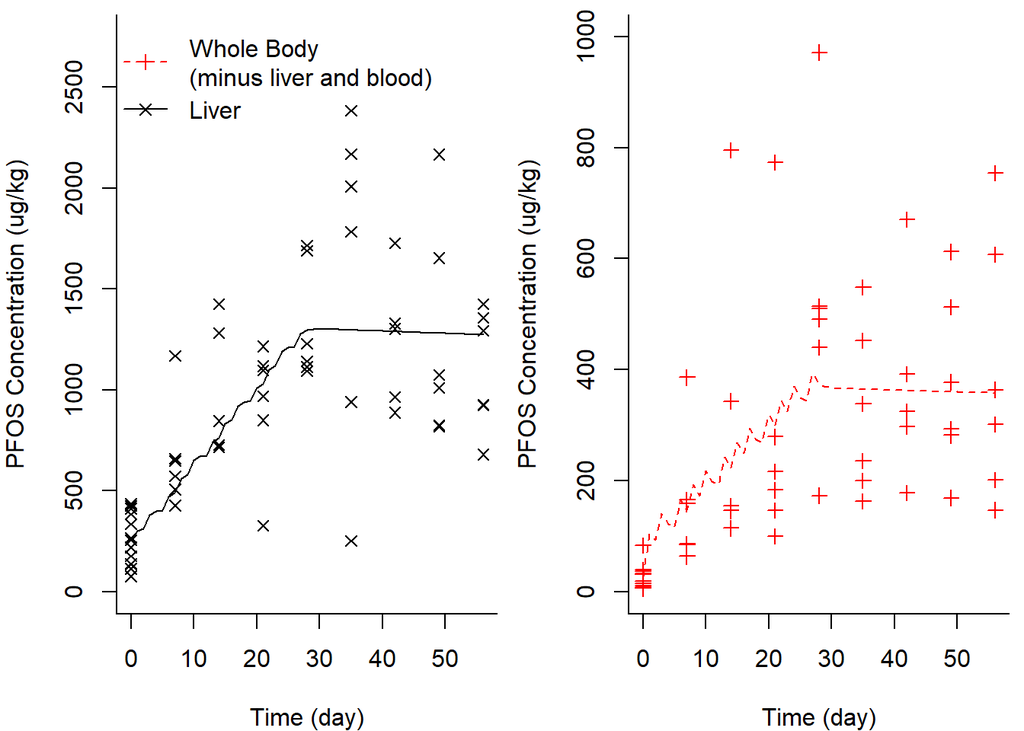

```r
out2 <- ode(y = state,

            times = times,

            func = pkmodel,

            parms = coef(fit),

            events = list(data=dose_data)) # or does LOOCV have to run all the way through here?



#plot(out2, obs=dat)



par(mfrow=c(1,2), mai=c(0.8,0.8,0.1,0.1))

plot(out2,

     which="liv",

     mfrow=NULL,

     xlab = "Time (day)",

     ylab= "PFOS Concentration (ug/kg)",

     ylim=c(0,2750), bty="l", type="l",

     main="")

points(liv~time, data=dat, col="black", pch=4)

legend("topleft", c("Whole Body\n(minus liver and blood)", "Liver"), col=c("Red","Black"), pch=c(3,4), lty=c(2,1), bty="n")

plot(out2,

     which="bod",

     mfrow=NULL,

     type="l",

     lty=2,

     col="red",

     xlab = "Time (day)",

     ylab= "PFOS Concentration (ug/kg)",

     ylim=c(0,1000), bty="l",

     main="")

points(bod~time, data=dat, col="red", pch=3)
```

```r
par(mfrow=c(1,2), mai=c(1,1,0.5,0.5))



cost2 <- function(p,e, data, ...) {

  #yy <- p[c("bod","liv")]

  pp <- p[c("k12","k21","kel")]#,"kel2")]

  out <- ode(y = state,

             times = times,

             func = pkmodel,

             parms = pp,

             events = list(data=e))

  modCost(out,dat, ...)

}



parmeters2 <- c(#bod=1, liv=250,

                k12 = 0.146,

                k21 = 0.007,

                kel = 0.007)#,

                #kel2=0.01)



fit2 <- modFit(f=cost2, p=parmeters2, e=dose_data, data=dat,  lower=0, upper=1)



summary(fit2)
```

```
##
## Parameters:
##     Estimate Std. Error t value Pr(>|t|)
## k12 0.999993   2.839376   0.352    0.725
## k21 0.282131   0.827239   0.341    0.734
## kel 0.003933   0.006357   0.619    0.537
##
## Residual standard error: 306.3 on 115 degrees of freedom
##
## Parameter correlation:
##          k12     k21      kel
## k12  1.00000  0.9988 -0.09444
## k21  0.99881  1.0000 -0.11756
## kel -0.09444 -0.1176  1.00000
```

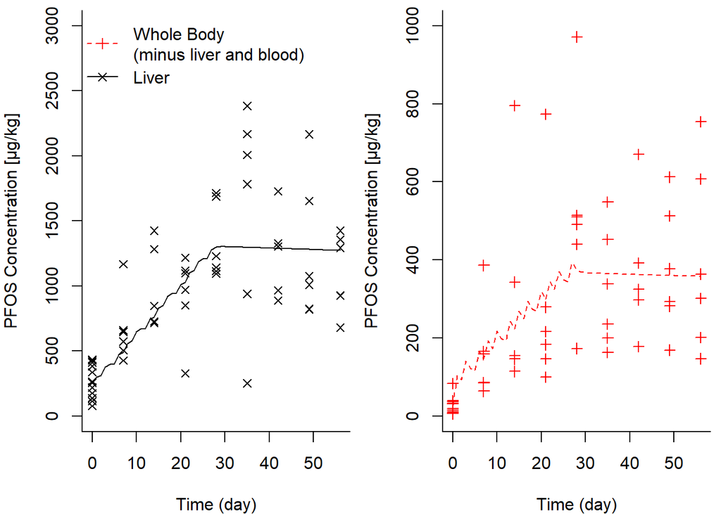

```r
out23 <- ode(y = state,

            times = times,

            func = pkmodel,

            parms = coef(fit2),

            events = list(data=dose_data))



#plot(out23, obs=dat)



par(mfrow=c(1,2), mai=c(0.8,0.8,0.1,0.1))

plot(out23,

     which="liv",

     mfrow=NULL,

     xlab = "Time (day)",

     ylab= "PFOS Concentration [\u03BCg/kg]",

     ylim=c(0,3000), bty="l", type="l",

     main="")

points(conc3~day, data=toad%>%filter(PFAS=="PFOS"&tissue=="Liver"), col="black", pch=4)

legend("topleft", c("Whole Body\n(minus liver and blood)", "Liver"), col=c("Red","Black"), pch=c(3,4), lty=c(2,1), bty="n")

plot(out23,

     which="bod",

     mfrow=NULL,

     type="l",

     lty=2,

     col="red",

     xlab = "Time (day)",

     ylab= "PFOS Concentration [\u03BCg/kg]",

     ylim=c(0,1000), bty="l",

     main="")

points(conc3~day, data=toad%>%filter(PFAS=="PFOS"&tissue=="Whole Body"), col="red", pch=3)
```

```r
par(mfrow=c(1,2), mai=c(1,1,0.5,0.5))
```

#### PFOS liver and whole body ODE new model

```r
pkmodel <- function(time, state, parmeters) {
  with(as.list(c(state, parmeters)), {
    dgut <- -k01*bod-poop*gut
    dbod <- k01*gut+k21*liv-k12*bod-kel*bod
    dliv <- k12*bod-k21*liv#-kel2*liv
    list(c(dgut,dbod, dliv))
  })
}



state <- c(gut=25,bod = 26.568, liv = 259.767) # initial concs

parmeters <- c(k12 = 0.5,
               k21 = 0.3,
               kel = 0.00001,
               k01 = 0.17,poop=0.5)#,
               #kel2 = 0.9)

times <- seq(0, 56, by=1) # start points to end points

dose_data <- data.frame(
  var=c("gut"),
  time=c(0,2,5,7,9,12,14,16,19,21,23,26),
  value=c(as.numeric(697.138)),
  method="add"
)





dat <- toad %>%
  filter(PFAS=="PFOS") %>%
  #filter(day!=28) %>%
  group_by(tissue,day)%>%#,toadID) %>%
  summarize(conc=mean(conc3)) %>%
  pivot_wider(names_from=tissue, values_from=conc) %>%
  rename(liv=Liver,
         bod=`Whole Body`,
         time=day) %>%
  #dplyr::select(-toadID) %>%
  ungroup() %>%
  data.frame()



cost <- function(p,e) {
  out <- ode(y = state,
             times = times,
             func = pkmodel,
             parms = p,
             events = list(data=e))

  modCost(out,dat, weight="none") # put this inside the LOOCV
}



fit <- modFit(f=cost, p=parmeters, e=dose_data,  lower=0, upper=1)

summary(fit)
```

```
##
## Parameters:
##       Estimate Std. Error t value Pr(>|t|)
## k12  1.000e+00  1.782e+00   0.561    0.584
## k21  2.950e-01  5.380e-01   0.548    0.593
## kel  7.216e-10  8.669e-02   0.000    1.000
## k01  1.746e-01  3.271e-01   0.534    0.603
## poop 7.632e-01  1.512e+00   0.505    0.622
##
## Residual standard error: 115 on 13 degrees of freedom
##
## Parameter correlation:
##          k12     k21     kel     k01    poop
## k12   1.0000  0.9976  0.4915 -0.5428 -0.5145
## k21   0.9976  1.0000  0.4798 -0.5342 -0.5066
## kel   0.4915  0.4798  1.0000 -0.9887 -0.9943
## k01  -0.5428 -0.5342 -0.9887  1.0000  0.9979
## poop -0.5145 -0.5066 -0.9943  0.9979  1.0000
```

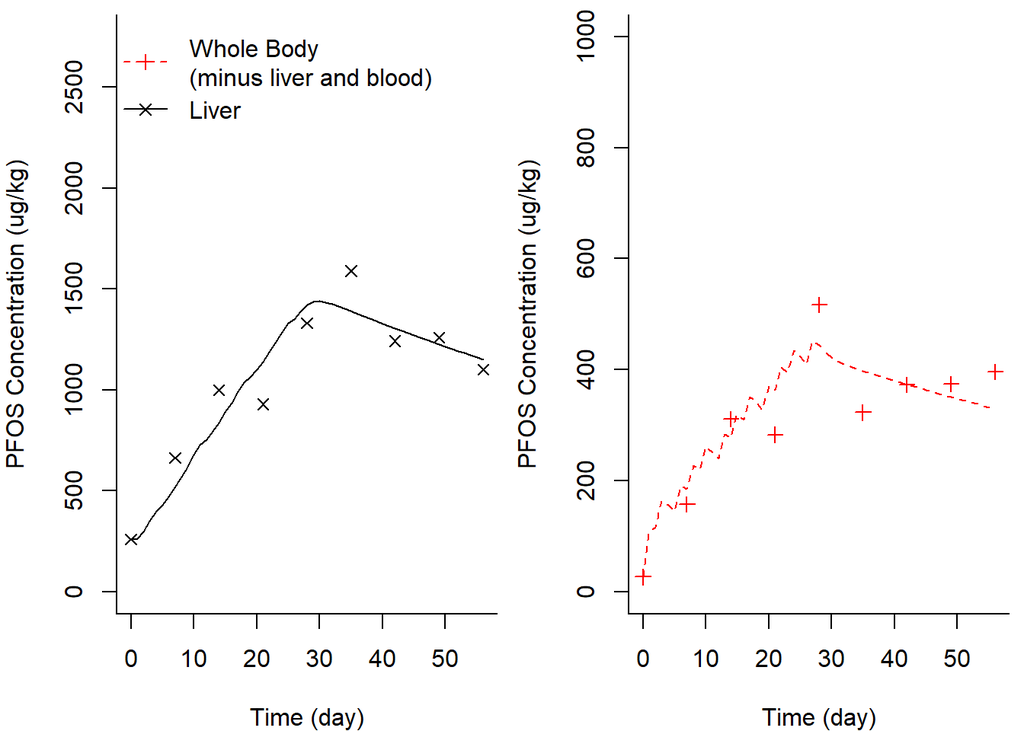

```r
out2 <- ode(y = state,
            times = times,
            func = pkmodel,
            parms = coef(fit),
            events = list(data=dose_data)) # or does LOOCV have to run all the way through here?



par(mfrow=c(1,2), mai=c(0.8,0.8,0.1,0.1))
plot(out2,
     which="liv",
     mfrow=NULL,
     xlab = "Time (day)",
     ylab= "PFOS Concentration (ug/kg)",
     ylim=c(0,2750), bty="l", type="l",
     main="")
points(liv~time, data=dat, col="black", pch=4)
legend("topleft", c("Whole Body\n(minus liver and blood)", "Liver"), col=c("Red","Black"), pch=c(3,4), lty=c(2,1), bty="n")
plot(out2,
     which="bod",
     mfrow=NULL,
     type="l",
     lty=2,
     col="red",
     xlab = "Time (day)",
     ylab= "PFOS Concentration (ug/kg)",
     ylim=c(0,1000), bty="l",
     main="")
points(bod~time, data=dat, col="red", pch=3)
```

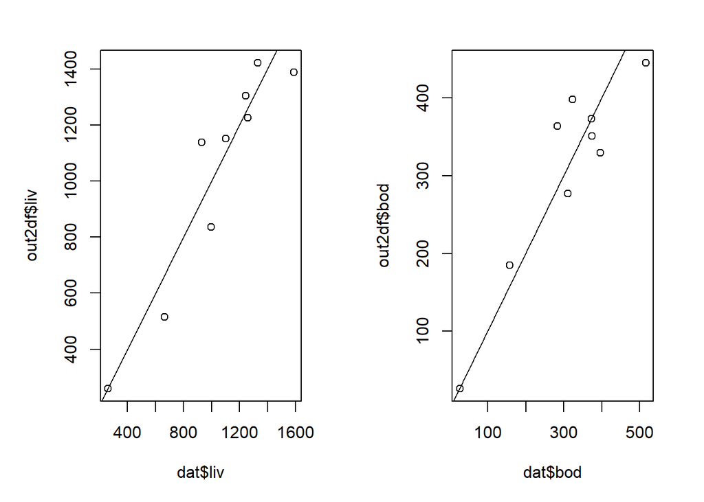

```r
par(mfrow=c(1,2), mai=c(1,1,0.5,0.5))

out2df <- data.frame(out2) %>% filter(time%in%unique(dat$time))
plot(dat$liv,out2df$liv)
abline(a=0,b=1)


plot(dat$bod,out2df$bod)
abline(a=0,b=1)
```

#### PFOS liver and whole body ODE LOOCV

Appears to be an improvement?

7% vs 2%

```r
subdat <- toad %>%

  filter(PFAS=="PFOS") %>%

  group_by(tissue,day,toadID) %>%

  summarize(conc=mean(conc3)) %>%

  pivot_wider(names_from=tissue, values_from=conc) %>%

  rename(liv=Liver,

         bod=`Whole Body`,

         time=day) %>%

  dplyr::select(-toadID) %>%

  ungroup() %>%

  data.frame()



pkmodel <- function(time, state, parmeters) {  # two compartment ODE system model

  with(as.list(c(state, parmeters)), {

    dbod <- k21*liv-k12*bod-kel*bod

    dliv <- k12*bod-k21*liv#-kel2*liv

    list(c(dbod, dliv))

  })

}





state <- c(bod = 26.568, liv = 259.767) # initial concs



parmeters <- c(k12 = 0.146,

               k21 = 0.007,

               kel = 0.007) # initial parameter estimates from nls()/lm()



times <- seq(0, 56, by=1) # start points to end points



dose_data <- data.frame(

  var=c("bod"),

  time=c(0,2,5,7,9,12,14,16,19,21,23,26),

  value=c(as.numeric(697.138*0.169)),

  method="add"

)







n <- length(subdat$time)

cvs <- rep(0,n)

cvs2 <- rep(0,n)

for(j in seq(n)){

  sds <- subdat[-j,]



  cost2 <- function(p,e) {

    out <- ode(y = state,

               times = times,

               func = pkmodel,

               parms = p,

               events = list(data=e))

    modCost(out, sds, weight="none")

  }

  fits <- modFit(f=cost2, p=parmeters, e=dose_data, lower=0, upper=1)



  outs <- data.frame(ode(y = state,

                         times = times,

                         func = pkmodel,

                         parms = coef(fits),

                         events = list(data=dose_data)))

  cvs[j] <- (subdat[j,2]-outs[j,2])^2

  cvs2[j] <- (subdat[j,3]-outs[j,3])^2

  print(paste0(j," of ",n," finished (",round(j/n*100),"%)"))

}
```

```
## [1] "1 of 59 finished (2%)"
## [1] "2 of 59 finished (3%)"
## [1] "3 of 59 finished (5%)"
## [1] "4 of 59 finished (7%)"
## [1] "5 of 59 finished (8%)"
## [1] "6 of 59 finished (10%)"
## [1] "7 of 59 finished (12%)"
## [1] "8 of 59 finished (14%)"
## [1] "9 of 59 finished (15%)"
## [1] "10 of 59 finished (17%)"
## [1] "11 of 59 finished (19%)"
## [1] "12 of 59 finished (20%)"
## [1] "13 of 59 finished (22%)"
## [1] "14 of 59 finished (24%)"
## [1] "15 of 59 finished (25%)"
```

[output cut: 44 more lines]

```r
cvs
```

```
##  [1] 5.785564e+04 5.373416e+04 2.677573e+04 6.213997e+03 6.897828e+04
##  [6] 4.004329e+02 7.281062e+04 7.027128e+04 5.455499e+04 7.815007e+00
## [11] 1.997136e+04 7.148024e+03 2.989332e+03 3.450750e+04 1.226475e+05
## [16] 1.528388e+05 1.577178e+05 4.475215e+04 7.940952e+05 1.325757e+06
## [21] 1.661670e+05 1.793369e+05 8.722699e+05 2.726871e+05 5.261440e+05
## [26] 3.796534e+02 6.091915e+05 3.291089e+05 2.264023e+05 7.149976e+05
## [31] 6.271743e+05 7.490073e+05 5.384376e+05 1.748961e+06 5.562185e+05
## [36] 1.824483e+06 4.074895e+06 3.224736e+06 2.698599e+06 1.196716e+04
## [41] 3.283301e+05 2.007144e+06 2.743508e+05 3.576878e+05 1.866487e+06
## [46] 9.531266e+05 8.822673e+05 1.660236e+06 2.127446e+05 3.299152e+06
## [51] 2.159296e+05 5.068621e+05 4.169509e+05 8.974627e+05 1.014476e+06
## [56] 1.142348e+06 3.148175e+05           NA           NA
```

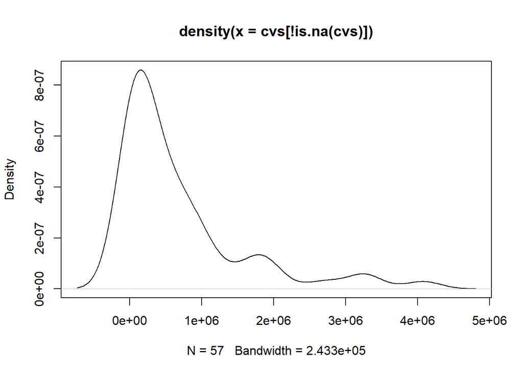

```r
plot(density(cvs[!is.na(cvs)]))
```

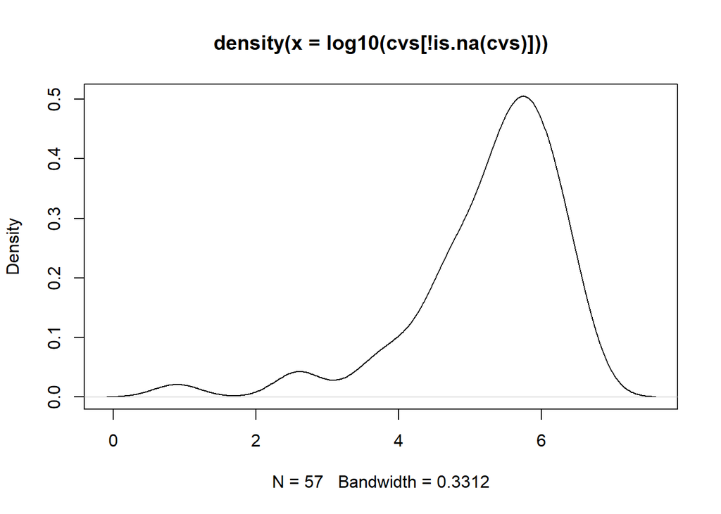

```r
plot(density(log10(cvs[!is.na(cvs)])))
```

```r
cvsode <- cvs

cvs2
```

```
##  [1]   31190.03   84870.65   75181.84  116095.78  153992.26  153924.84
##  [7]  203959.67  208540.05  280461.11  319608.86  374036.72  424099.86
## [13]  445618.78  430045.42  353294.36  198195.23  617442.79  698155.40
## [19]  607767.46  617172.69  804795.92   56687.55  903431.06  602080.54
## [25] 1010613.92 1243165.15  195750.48 1284075.91 1172881.91 1040665.60
## [31]  114527.30  745238.86  625911.82  642743.10 1269756.59  608579.98
## [37]  523012.88 1151593.50  678814.36 1171213.59 1293079.81  881586.30
## [43]  954251.28 1254638.76  775427.29  375916.75  974519.31 1210653.04
## [49]  853907.27  532207.89  471040.20  992129.38 1018972.07  267357.36
## [55]  435857.73  813934.11  986084.19         NA         NA
```

```r
mean(cvs, na.rm=T)
```

```
## [1] 690799.4
```

```r
mean(cvs2, na.rm=T)
```

```
## [1] 637381.7
```

```r
sqrt(sum(cvs, na.rm=T)/n) # standard deviation of predicted errors
```

```
## [1] 816.9348
```

```r
cost <- function(p,e) {

  out <- ode(y = state,

             times = times,

             func = pkmodel,

             parms = p,

             events = list(data=e))

  modCost(out,subdat, weight="none") # put this inside the LOOCV

}



fitfull <- modFit(f=cost, p=parmeters, e=dose_data, lower=0, upper=1)

#summary(fitfull)



outfull <- ode(y = state,

            times = times,

            func = pkmodel,

            parms = coef(fitfull),

            events = list(data=dose_data))





nfull <- length(subdat$time)

cvsfull <- rep(0,nfull)

cvs2full <- rep(0,nfull)

cvsfull <- (subdat[,2]-outfull[,2])^2
cvs2full <- (subdat[,3]-outfull[,3])^2
mean(cvsfull)
```

```
## [1] 686183.5
```

```r
sqrt(sum(cvsfull, na.rm=T)/n) # standard deviation of predicted errors
```

```
## [1] 828.3619
```

```r
mean(cvs2full)
```

```
## [1] 616668.4
```

```r
sqrt(sum(cvs2full, na.rm=T)/n) # standard deviation of predicted errors
```

```
## [1] 785.2824
```

```r
mean((cvsfull-cvs)/cvsfull, na.rm=T)
```

```
## [1] 0.004165563
```

```r
LOOCVPFOSODE <- data.frame(

  tissue=c("liver","body"),

  full=c(mean(cvsfull), mean(cvs2full)),

  LOO=c(mean(cvs, na.rm=T), mean(cvs2, na.rm=T))

  ) |>

  group_by(tissue) |>

  mutate(perc_diff=(full-LOO)/full)



kable(LOOCVPFOSODE)
```

| tissue | full | LOO | perc_diff |
| --- | --- | --- | --- |
| liver | 686183.5 | 690799.4 | -0.0067269 |
| body | 616668.4 | 637381.7 | -0.0335890 |

## Comparison of PFOS liver MSEs

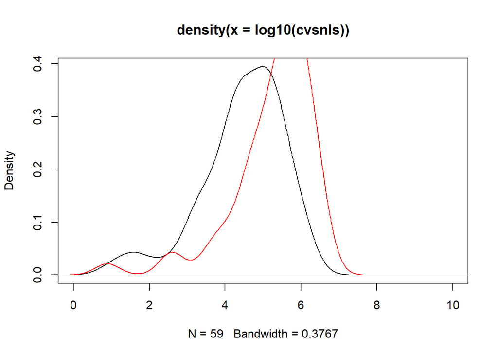

```r
plot(density(log10(cvsnls)), xlim=c(0,10))
points(density(log10(cvsode[!is.na(cvsode)])), type="l", col="red")
```

#### 8:2 FTS liver and whole body ODE

```r
pkmodel <- function(time, state, parmeters) {

  with(as.list(c(state, parmeters)), {

    dbod <- k21*liv-k12*bod-kel*bod

    dliv <- k12*bod-k21*liv#-kel2*liv

    list(c(dbod, dliv))

  })

}



state <- c(bod = 0.1, liv = 0.1) # initial concs

parmeters <- c(k12 = 0.938,

               k21 = 0.108,

               kel = 0.091)#,

               #kel2 = 0.1)

times <- seq(0, 56, 1) # start points to end points

dose_data <- data.frame(

  var=c("bod","liv"),

  time=c(0,0,2,2,5,5,7,7,9,9,12,12,14,14,16,16,19,19,21,21,23,23,26,26),

  value=c(as.numeric(885.228*0.1),as.numeric(885.228*0.001)),

  method="add"

)









# calcuate differential equation with parameters

# and initialized state values

#out <- ode(y = state,

#           times = times,

#           func = pkmodel,

#           parms = parmeters,

#           events = list(data=dose_data))

#out <- as.data.frame(out)

#

#par(mfrow=c(1,2), mai=c(0.8,0.8,0.1,0.1))

#plot(out$time,

#     out$liv,

#     xlab = "Time (day)",

#     ylab= "PFOS Concentration (ug/kg)",

#     type = 'l',ylim=c(0,2750), bty="l")

#points(conc3~day, data=toad%>%filter(PFAS=="PFOS"&tissue=="Liver"), col="black", pch=4)

#legend("topleft", c("Whole Body (minus liver)", "Liver"), col=c("Red","Black"), pch=c(3,4), lty=c(2,1), bty="n")

#plot(out$time,

#     out$bod,

#     type="l",

#     lty=2,

#     col="red",

#     xlab = "Time (day)",

#     ylab= "PFOS Concentration (ug/kg)",

#     ylim=c(0,2750), bty="l")

#points(conc3~day, data=toad%>%filter(PFAS=="PFOS"&tissue=="Whole Body"), col="red", pch=3)

#par(mfrow=c(1,2), mai=c(1,1,0.5,0.5))





#dat <- data.frame(

#  time=seq(0,56,7),

#  liv=toad%>%filter(PFAS=="PFOS"&tissue=="liver")%>%group_by(day)%>%summarize(liv=mean(conc2))%>%ungroup()%>%dplyr::select(liv),

#  bod=toad%>%filter(PFAS=="PFOS"&tissue=="wholebody")%>%group_by(day)%>%summarize(bod=mean(conc2))%>%ungroup()%>%dplyr::select(bod)

#  #time=toad%>%filter(PFAS=="PFOS"&tissue=="liver")%>%dplyr::select(day)%>%dplyr::rename(time=day),

#  time=toad$day[toad$PFAS=="PFOS"&toad$tissue=="liver"],

#  #liv=toad%>%filter(PFAS=="PFOS"&tissue=="liver")%>%dplyr::select(conc2)%>%dplyr::rename(liv=conc2),

#  liv=toad$conc2[toad$PFAS=="PFOS"&toad$tissue=="liver"],

#  #bod=toad%>%filter(PFAS=="PFOS"&tissue=="wholebody")%>%dplyr::select(conc2)%>%dplyr::rename(bod=conc2)

#  bod=toad$conc2[toad$PFAS=="PFOS"&toad$tissue=="wholebody"]

#)



dat <- toad %>%

  filter(PFAS=="8:2 FTS") %>%

  group_by(tissue,day,toadID) %>%

  summarize(conc=mean(conc3)) %>%

  pivot_wider(names_from=tissue, values_from=conc) %>%

  rename(liv=Liver,

         bod=`Whole Body`,

         time=day) %>%

  dplyr::select(-toadID) %>%

  ungroup() %>%

  data.frame()





cost <- function(p,e) {

  out <- ode(y = state,

             times = times,

             func = pkmodel,

             parms = p,

             events = list(data=e))

  modCost(out,dat, weight="none")

}



fit <- modFit(f=cost, p=parmeters, e=dose_data)

summary(fit)
```

```
##
## Parameters:
##     Estimate Std. Error t value Pr(>|t|)
## k12  0.27543    0.07721   3.567 0.000527 ***
## k21  0.20478    0.05355   3.824 0.000214 ***
## kel  0.48123    0.03866  12.449  < 2e-16 ***
## ---
## Signif. codes:  0 '***' 0.001 '**' 0.01 '*' 0.05 '.' 0.1 ' ' 1
##
## Residual standard error: 23.91 on 115 degrees of freedom
##
## Parameter correlation:
##        k12     k21     kel
## k12 1.0000 0.93400 0.34490
## k21 0.9340 1.00000 0.06431
## kel 0.3449 0.06431 1.00000
```

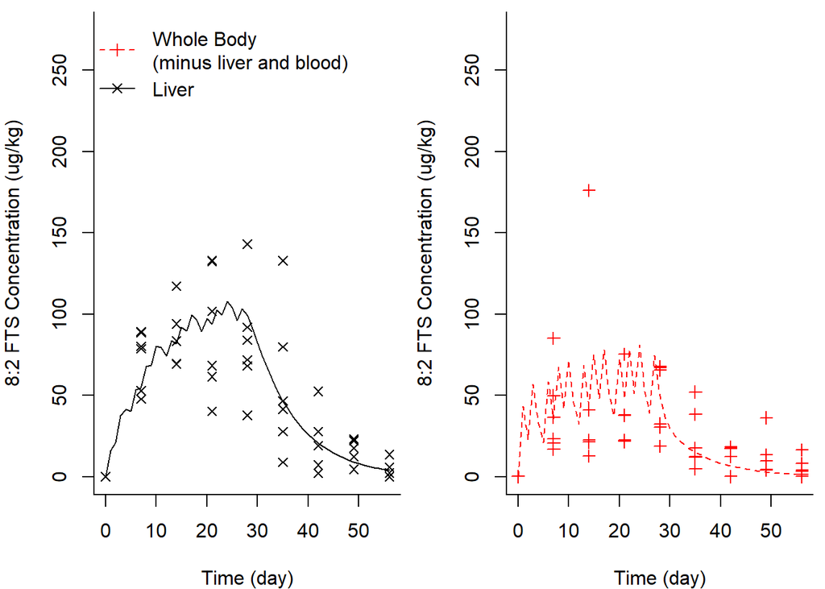

```r
out2 <- ode(y = state,

            times = times,

            func = pkmodel,

            parms = coef(fit),

            events = list(data=dose_data))



#plot(out2, obs=dat)



par(mfrow=c(1,2), mai=c(0.8,0.8,0.1,0.1))

plot(out2,

     which="liv",

     mfrow=NULL,

     xlab = "Time (day)",

     ylab= "8:2 FTS Concentration (ug/kg)",

     ylim=c(0,275), bty="l", type="l",

     main="")

points(conc3~day, data=toad%>%filter(PFAS=="8:2 FTS"&tissue=="Liver"), col="black", pch=4)

legend("topleft", c("Whole Body\n(minus liver and blood)", "Liver"), col=c("Red","Black"), pch=c(3,4), lty=c(2,1), bty="n")

plot(out2,

     which="bod",

     mfrow=NULL,

     type="l",

     lty=2,

     col="red",

     xlab = "Time (day)",

     ylab= "8:2 FTS Concentration (ug/kg)",

     ylim=c(0,275), bty="l",

     main="")

points(conc3~day, data=toad%>%filter(PFAS=="8:2 FTS"&tissue=="Whole Body"), col="red", pch=3)
```

```r
par(mfrow=c(1,2), mai=c(1,1,0.5,0.5))



cost2 <- function(p,e, data, ...) {

  #yy <- p[c("bod","liv")]

  pp <- p[c("k12","k21","kel")]#,"kel2")]

  out <- ode(y = state,

             times = times,

             func = pkmodel,

             parms = pp,

             events = list(data=e))

  modCost(out,dat, ...)

}



parmeters2 <- c(#bod=1, liv=250,

                k12 = 0.938,

                k21 = 0.108,

                kel = 0.091)#,

                #kel2=0.01)



fit2 <- modFit(f=cost2, p=parmeters2, e=dose_data, data=dat, method="Marq")



summary(fit2)
```

```
##
## Parameters:
##     Estimate Std. Error t value Pr(>|t|)
## k12  0.27543    0.07721   3.567 0.000527 ***
## k21  0.20478    0.05355   3.824 0.000214 ***
## kel  0.48123    0.03866  12.449  < 2e-16 ***
## ---
## Signif. codes:  0 '***' 0.001 '**' 0.01 '*' 0.05 '.' 0.1 ' ' 1
##
## Residual standard error: 23.91 on 115 degrees of freedom
##
## Parameter correlation:
##        k12     k21     kel
## k12 1.0000 0.93400 0.34490
## k21 0.9340 1.00000 0.06431
## kel 0.3449 0.06431 1.00000
```

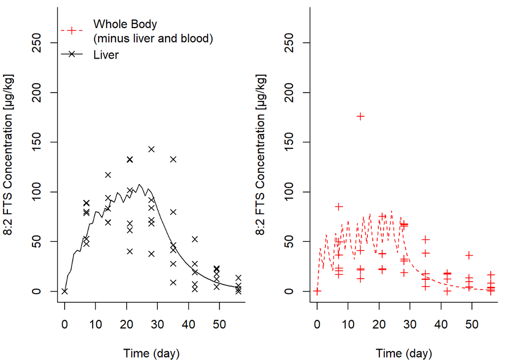

```r
out23 <- ode(y = state,

            times = times,

            func = pkmodel,

            parms = coef(fit2),

            events = list(data=dose_data))



#plot(out23, obs=dat)



par(mfrow=c(1,2), mai=c(0.8,0.8,0.1,0.1))

plot(out23,

     which="liv",

     mfrow=NULL,

     xlab = "Time (day)",

     ylab= "8:2 FTS Concentration [\u03BCg/kg]",

     ylim=c(0,275), bty="l", type="l",

     main="")

points(conc3~day, data=toad%>%filter(PFAS=="8:2 FTS"&tissue=="Liver"), col="black", pch=4)

legend("topleft", c("Whole Body\n(minus liver and blood)", "Liver"), col=c("Red","Black"), pch=c(3,4), lty=c(2,1), bty="n")

plot(out23,

     which="bod",

     mfrow=NULL,

     type="l",

     lty=2,

     col="red",

     xlab = "Time (day)",

     ylab= "8:2 FTS Concentration [\u03BCg/kg]",

     ylim=c(0,275), bty="l",

     main="")

points(conc3~day, data=toad%>%filter(PFAS=="8:2 FTS"&tissue=="Whole Body"), col="red", pch=3)
```

```r
par(mfrow=c(1,2), mai=c(1,1,0.5,0.5))
```

```r
pkmodel <- function(time, state, parmeters) {
  with(as.list(c(state, parmeters)), {
    dgut <- -k01*bod-poop*gut
    dbod <- k01*gut+k21*liv-k12*bod-kel*bod
    dliv <- k12*bod-k21*liv#-kel2*liv
    list(c(dgut,dbod, dliv))
  })
}



state <- c(gut=0.1,bod = 0.1, liv = 0.1) # initial concs

parmeters <- c(k12 = 0.5,
               k21 = 0.3,
               kel = 0.00001,
               k01 = 0.17,poop=0.5)#,
               #kel2 = 0.9)

times <- seq(0, 56, by=1) # start points to end points

dose_data <- data.frame(
  var=c("gut"),
  time=c(0,2,5,7,9,12,14,16,19,21,23,26),
  value=c(as.numeric(885.228)),
  method="add"
)





dat <- toad %>%
  filter(PFAS=="8:2 FTS") %>%
  group_by(tissue,day)%>%#,toadID) %>%
  summarize(conc=median(conc3)) %>%
  pivot_wider(names_from=tissue, values_from=conc) %>%
  rename(liv=Liver,
         bod=`Whole Body`,
         time=day) %>%
  #dplyr::select(-toadID) %>%
  ungroup() %>%
  data.frame()



cost <- function(p,e) {
  out <- ode(y = state,
             times = times,
             func = pkmodel,
             parms = p,
             events = list(data=e))

  modCost(out,dat, weight="none") # put this inside the LOOCV
}



fit <- modFit(f=cost, p=parmeters, e=dose_data,  lower=0, upper=1)

summary(fit)
```

```
##
## Parameters:
##      Estimate Std. Error t value Pr(>|t|)
## k12    0.5000     1.0303   0.485    0.636
## k21    0.2364     0.3142   0.752    0.465
## kel    1.0000     1.4052   0.712    0.489
## k01    0.1251     0.5922   0.211    0.836
## poop   0.9990     4.4211   0.226    0.825
##
## Residual standard error: 11.71 on 13 degrees of freedom
##
## Parameter correlation:
##          k12     k21     kel     k01    poop
## k12   1.0000  0.9713  0.0386 -0.9380 -0.8095
## k21   0.9713  1.0000 -0.1715 -0.8407 -0.6639
## kel   0.0386 -0.1715  1.0000 -0.3374 -0.5939
## k01  -0.9380 -0.8407 -0.3374  1.0000  0.9571
## poop -0.8095 -0.6639 -0.5939  0.9571  1.0000
```

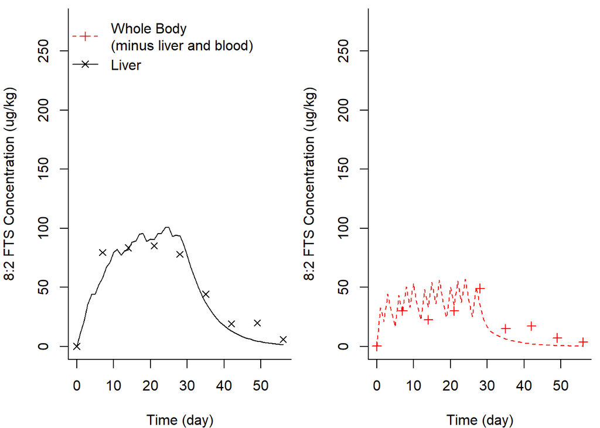

```r
out2 <- ode(y = state,
            times = times,
            func = pkmodel,
            parms = coef(fit),
            events = list(data=dose_data)) # or does LOOCV have to run all the way through here?



par(mfrow=c(1,2), mai=c(0.8,0.8,0.1,0.1))
plot(out2,
     which="liv",
     mfrow=NULL,
     xlab = "Time (day)",
     ylab= "8:2 FTS Concentration (ug/kg)",
     ylim=c(0,275), bty="l", type="l",
     main="")
points(liv~time, data=dat, col="black", pch=4)
legend("topleft", c("Whole Body\n(minus liver and blood)", "Liver"), col=c("Red","Black"), pch=c(3,4), lty=c(2,1), bty="n")
plot(out2,
     which="bod",
     mfrow=NULL,
     type="l",
     lty=2,
     col="red",
     xlab = "Time (day)",
     ylab= "8:2 FTS Concentration (ug/kg)",
     ylim=c(0,275), bty="l",
     main="")
points(bod~time, data=dat, col="red", pch=3)
```

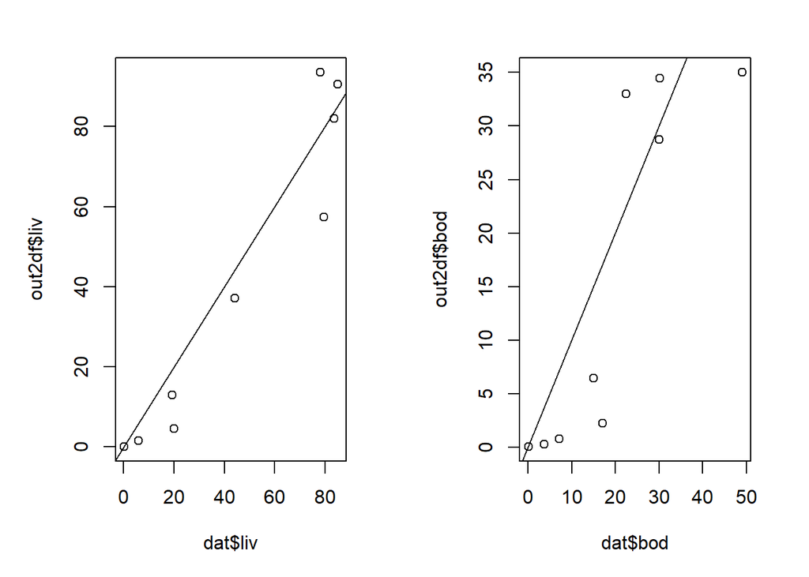

```r
par(mfrow=c(1,2), mai=c(1,1,0.5,0.5))

out2df <- data.frame(out2) %>% filter(time%in%unique(dat$time))
plot(dat$liv,out2df$liv)
abline(a=0,b=1)

out2df <- data.frame(out2) %>% filter(time%in%unique(dat$time))
plot(dat$bod,out2df$bod)
abline(a=0,b=1)
```

#### 8:2 FTS liver and whole body ODE LOOCV

Appears to be an improvement?

7% vs 2%

```r
subdat <- toad %>%

  filter(PFAS=="8:2 FTS") %>%

  group_by(tissue,day,toadID) %>%

  summarize(conc=mean(conc3)) %>%

  pivot_wider(names_from=tissue, values_from=conc) %>%

  rename(liv=Liver,

         bod=`Whole Body`,

         time=day) %>%

  dplyr::select(-toadID) %>%

  ungroup() %>%

  data.frame()



pkmodel <- function(time, state, parmeters) {  # two compartment ODE system model

  with(as.list(c(state, parmeters)), {

    dbod <- k21*liv-k12*bod-kel*bod

    dliv <- k12*bod-k21*liv#-kel2*liv

    list(c(dbod, dliv))

  })

}





state <- c(bod = 0.1, liv = 0.1) # initial concs



parmeters <- c(k12 = 0.938,

               k21 = 0.108,

               kel = 0.091) # initial parameter estimates from nls()/lm()



times <- seq(0, 56, by=1) # start points to end points



dose_data <- data.frame(                 # dosing schedule--add value to specific tissues at times

  var=c("bod","liv"),

  time=c(0,0,2,2,5,5,7,7,9,9,12,12,14,14,16,16,19,19,21,21,23,23,26,26),

  value=c(as.numeric(885.228*0.1),as.numeric(885.228*0.001)),

  method="add"

)







n <- length(subdat$time)

cvs <- rep(0,n)

cvs2 <- rep(0,n)

for(j in seq(n)){

  sds <- subdat[-j,]



  cost2 <- function(p,e) {

    out <- ode(y = state,

               times = times,

               func = pkmodel,

               parms = p,

               events = list(data=e))

    modCost(out, sds, weight="none")

  }

  fits <- modFit(f=cost2, p=parmeters, e=dose_data)



  outs <- data.frame(ode(y = state,

                         times = times,

                         func = pkmodel,

                         parms = coef(fits),

                         events = list(data=dose_data)))

  cvs[j] <- (subdat[j,2]-outs[j,2])^2

  cvs2[j] <- (subdat[j,3]-outs[j,3])^2

  print(paste0(j," of ",n," finished (",round(j/n*100),"%)"))

}
```

```
## [1] "1 of 59 finished (2%)"
## [1] "2 of 59 finished (3%)"
## [1] "3 of 59 finished (5%)"
## [1] "4 of 59 finished (7%)"
## [1] "5 of 59 finished (8%)"
## [1] "6 of 59 finished (10%)"
## [1] "7 of 59 finished (12%)"
## [1] "8 of 59 finished (14%)"
## [1] "9 of 59 finished (15%)"
## [1] "10 of 59 finished (17%)"
## [1] "11 of 59 finished (19%)"
## [1] "12 of 59 finished (20%)"
## [1] "13 of 59 finished (22%)"
## [1] "14 of 59 finished (24%)"
## [1] "15 of 59 finished (25%)"
```

[output cut: 44 more lines]

```r
cvs
```

```
##  [1] 0.000000e+00 1.852509e+03 5.263332e+02 3.236425e+03 1.052645e+03
##  [6] 4.432851e+02 3.416430e+03 1.240837e+03 4.516728e+03 1.710790e+03
## [11] 5.177615e+03 2.050471e+03 1.039017e+03 4.084009e+02 1.243201e+03
## [16] 2.386915e+02 1.627380e+01 9.679631e+02 8.710060e+02 9.785103e+02
## [21] 9.269130e+01 2.750015e+03 1.162017e+02 4.315923e+03 2.638580e+03
## [26] 2.107238e+02 5.464626e+02 3.165109e+03 2.991031e+02 4.167079e+03
## [31] 3.968369e+03 3.534094e+03 2.270498e+02 2.340159e+03 2.935320e+03
## [36] 1.654676e+04 8.006067e+02 2.511631e+02 4.839612e+03 3.755869e-01
## [41] 1.470555e+03 1.599778e+04 1.576685e+02 1.399366e+01 2.260368e+03
## [46] 6.535913e+00 5.671310e+02 3.626182e+02 4.043481e+02 8.741914e+01
## [51] 3.853702e+02 2.365193e+02 6.484396e+00 1.397066e+02 1.931251e+01
## [56] 1.928840e+01 2.071808e+01           NA           NA
```

```r
cvs2
```

```
##  [1] 0.000000e+00 2.608525e+02 4.396201e+02 1.416446e+03 1.705737e+03
##  [6] 1.608167e+03 2.837606e+03 2.982645e+03 4.602517e+03 4.664134e+03
## [11] 6.451723e+03 6.325437e+03 5.510067e+03 3.384434e+03 9.530837e+02
## [16] 2.774090e+01 4.783415e+03 6.858400e+03 3.445695e+03 4.730993e+03
## [21] 5.574750e+03 6.882066e+03 8.210552e+03 3.170301e+03 4.572526e+03
## [26] 7.269496e+03 4.934043e+02 6.152878e+03 6.209429e+03 2.821912e+03
## [31] 2.302034e+02 5.652136e+01 1.481565e+03 7.744132e+02 1.217648e+03
## [36] 4.257674e+02 5.978744e+02 1.143544e+03 6.648708e+01 3.976935e+02
## [41] 2.009723e+02 1.266031e+03 7.051487e+01 3.717708e+02 1.222707e+01
## [46] 4.130034e+00 2.480430e+01 5.281923e+01 1.304537e+01 2.092013e+01
## [51] 8.130316e+02 7.845008e+00 3.804825e+00 1.188809e+02 8.996810e+00
## [56] 1.369319e+00 1.526565e-03           NA           NA
```

```r
mean(cvs, na.rm=T)
```

```
## [1] 1875.234
```

```r
mean(cvs2, na.rm=T)
```

```
## [1] 2170.683
```

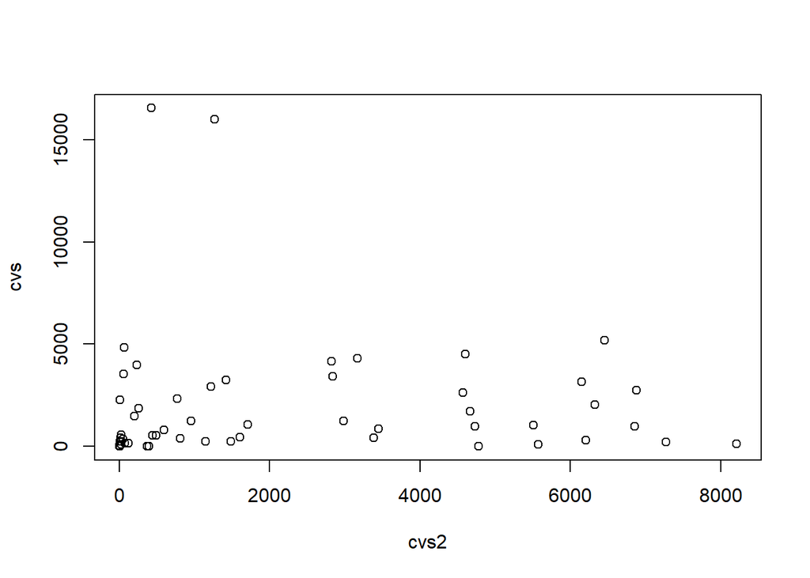

```r
plot(cvs~cvs2)
```

```r
cost <- function(p,e) {

  out <- ode(y = state,

             times = times,

             func = pkmodel,

             parms = p,

             events = list(data=e))

  modCost(out,subdat, weight="none") # put this inside the LOOCV

}



fitfull <- modFit(f=cost, p=parmeters, e=dose_data)

#summary(fitfull)



outfull <- ode(y = state,

            times = times,

            func = pkmodel,

            parms = coef(fitfull),

            events = list(data=dose_data))





nfull <- length(subdat$time)

cvsfull <- rep(0,nfull)

cvs2full <- rep(0,nfull)

cvsfull <- (subdat[,2]-outfull[,2])^2
cvs2full <- (subdat[,3]-outfull[,3])^2
mean(cvsfull)
```

```
## [1] 1830.046
```

```r
mean(cvs2full)
```

```
## [1] 2086.593
```

```r
LOOCV82FTSODE <- data.frame(

  tissue=c("liver","body"),

  full=c(mean(cvsfull), mean(cvs2full)),

  LOO=c(mean(cvs, na.rm=T), mean(cvs2, na.rm=T))

  ) |>

  group_by(tissue) |>

  mutate(perc_diff=(full-LOO)/full)



kable(LOOCV82FTSODE)
```

| tissue | full | LOO | perc_diff |
| --- | --- | --- | --- |
| liver | 1830.046 | 1875.234 | -0.0246926 |
| body | 2086.593 | 2170.683 | -0.0403000 |